# Negative Binomial Group Sequential Designs

Recurrent-event outcomes and information-based SSR in gsDesignNB

Keaven M. Anderson, Hongtao Zhang, Andrea Maes

Merck & Co., Inc., Rahway, NJ, USA

2026-04-28

## Talk plan

**~25 min** talk · **~5 min** discussion (30 min slot)

| Block | Minutes | Focus |
| --- | --- | --- |
| Why NB? | ~3 | Poisson vs NB, overdispersion in practice |
| Motivation & “three gaps” | ~4 | Why NB planning can misstate information |
| Expected events & timing | ~5 | NB model + information timing |
| GSD, simulation, SSR | ~7 | gsDesign backend, NB workflows, Jensen sweep |
| Software verification | ~3 | Reproducible workflows, validation, development provenance |
| Conclusions & wrap-up | ~3 | Takeaways, software map |

## Why not just Poisson?

Poisson counts assume every patient has the **same event rate**, but real recurrent-event trials show:

- **Between-patient heterogeneity** — sicker patients contribute many events while most contribute few.
- **Overdispersion** — observed variance exceeds the Poisson mean, so Poisson-based tests are **anticonservative** or power calculations **overstate** true power.
- **Heavy tails** — extra-Poisson variation inflates the tail of the count distribution.

The **negative binomial (NB)** model adds one parameter, the **dispersion** $k$, to capture this heterogeneity.

## Overdispersion in practice

Published NB dispersion estimates from pivotal / large trials:

[output not shown]

- Even $k=0.5$ materially reduces per-patient information: $\mathscr{I}_i=\mu_i/(1+k\mu_i)$.
- Ignoring $k$ → **understated sample size** by 10–30 %.

## NB count distribution intuition

Same mean $\mu=5$; larger $k$ → more spread, heavier tails → **more patients needed**.

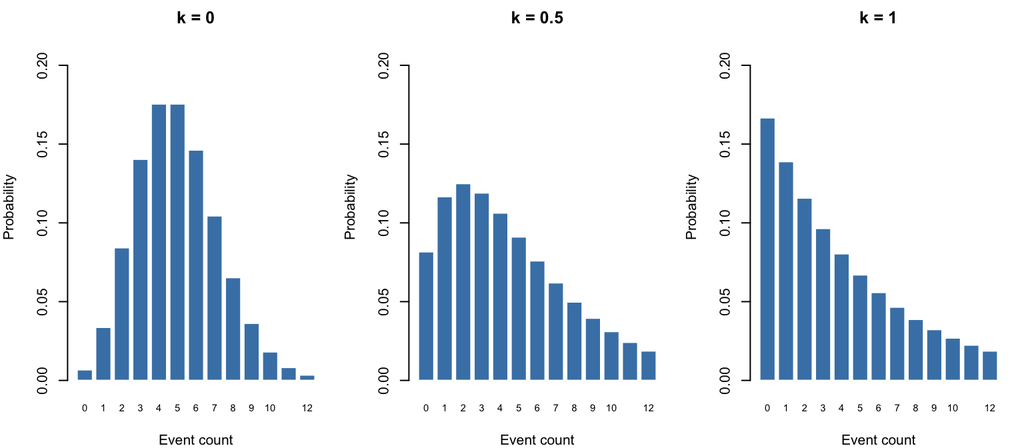

- Per-subject information: $\mathscr{I}_i = \mu_i/(1+k\mu_i)$ — at $k=0$ we recover Poisson; as $k$ grows, each event carries **less** information.

## Standard toolkit vs trial reality

- **Standard:** fixed negative binomial design → **target information** → **gsDesign**-backed boundaries.
- **Reality:** interims potentially mix **calendar rules**, **minimum follow-up**, **information targets**, and **mandatory time between database locks** while events accrue.

## “Gaps between events” — three senses

- **Operational / calendar:** successive looks no earlier than $\tau_{i-1}+\Delta_i$ (trial clock).
- **Timing / accrual structure:** piecewise accrual or dropout support nonuniform information growth.
- **Patient-level:** only events separated by at least $\delta$ **patient time** count toward the protocol total; closer events for the same patient are **discarded** in simulation.

## Why calendar gaps matter for sample size

Interim times solve **feasibility inequalities**:

- Calendar floor: $\tau_i \ge C_i$
- **Gap after previous look:** $\tau_i \ge \tau_{i-1}+\Delta_i$
- Exposure / enrollment constraints
- **Information threshold:** smallest trial time $t$ with expected (or observed) information $\ge \mathscr{I}_i$, **subject to** the floors

**Take the max** of applicable floors, then lift further if information requires it — the same backend timing logic applies once the information path is specified.

**Maximum per patient follow-up** (e.g., 1 year) can cap trial duration.

## NB recurrent-event model

- **Default patient model:** conditional on treatment arm $g$, recurrent events follow a Poisson process with rate $\lambda_g$ (events per unit time).
- **Gamma frailty:** each subject has a latent rate $\Lambda_i \sim \text{Gamma}(1/k,\; k\lambda_g)$, generating events from $\text{Poisson}(\Lambda_i \, t_i)$. Marginalizing gives NB counts with mean $\mu_i = \lambda_g t_i$ and variance $\mu_i + k\mu_i^2$.
- **Dispersion** $k$: controls patient heterogeneity — $k=0$ is Poisson; larger $k$ means heavier tails and **less information per expected event**.
- **Time-varying extension:** `nb_sim_seasonal()` for season-specific rates.
- **Piecewise accrual / dropout** and expected-event formulas are **timing infrastructure**; information depends on **exposure, rates, and dispersion**, not events alone.
- **Per patient maximum follow-up**; e.g., 1 year.

## Dropout, MAR, and MI scope

- **Dropout in gsDesignNB:** handled as exposure truncation; partial follow-up stays in the analysis through counted events and observed time at risk.
- **Planning and SSR:** `sample_size_nbinom()` accounts for planned dropout / maximum follow-up; SSR uses observed interim exposure, then recalculates total $N$ under the planned dropout assumptions.
- **Under MAR / ignorable censoring:** observed-data NB likelihood with an exposure offset gives valid rate-ratio estimates and model-based variances; **MI is not required** simply because follow-up is censored.
- **Under MNAR:** MI is a sensitivity-analysis tool; Keene et al. (2014) give a recurrent-event controlled-imputation template using reference-based assumptions.
- If protocol event gaps matter, MNAR MI should impute **event times** when possible, then re-apply the counting rule.

## NB distribution: parameters

For subject $i$ in treatment group $g$ with exposure $t_i$:

- **Event count** $Y_i \sim \text{NB}(\mu_i, k)$
- **Mean:** $\mu_i = \lambda_g \, t_i$ where $\lambda_g$ = event rate (events/month) in arm $g$
- **Variance:** $\text{Var}(Y_i) = \mu_i + k\,\mu_i^2$
- **Dispersion** $k$: measures patient heterogeneity (gamma frailty variance)
  - $k = 0$: Poisson (no overdispersion)
  - $k$ large: heavy-tailed, more variable outcomes

| Symbol | Meaning |
| --- | --- |
| $\lambda_g$ | Event rate in arm $g$ (events per unit time) |
| $t_i$ | Exposure time for subject $i$ |
| $\mu_i = \lambda_g t_i$ | Expected event count for subject $i$ |
| $k$ | Dispersion (overdispersion parameter) |
| $\theta = \log(\lambda_2/\lambda_1)$ | Treatment effect (log rate ratio) |

## Patient-level minimum gap $\delta$ (counting rule)

Potential event times per patient $T_{j,1}<T_{j,2}<\cdots$.

**Counted** sequence: first event counts; next **counted** event is the **first** potential event at or after **previous counted** $+\,\delta$; events in between are **excluded** from the trial event total.

- **Effect:** thins recurrent / dense outcomes → **slower** information vs naive expected-event formulas that count every failure.

## Trial-level $\Delta$ vs patient-level $\delta$

|  | $\Delta_i$ between interims ($\tau$-scale) | $\delta$ between patient events ($T$-scale) |
| --- | --- | --- |
| **Scale** | Trial / database-lock calendar | Per-patient timeline |
| **Role** | **When** looks may occur | **Which** events contribute to information |

Designs that ignore $\delta$ can misstate **information** and **power** if the SAP applies thinning.

## Sample size formula and information

- **Implemented formula:** `sample_size_nbinom()` uses the Wald log rate-ratio test from **Zhu & Lakkis (2014, Method 3)**.
- **Same variance foundation:** the same NB Wald variance underlies **Friede & Schmidli (2010)** for blinded SSR and **Mutze et al. (2019)** for group sequential NB designs.

$$n_{\text{total}} \propto
\frac{(z_{\alpha/s}+z_\beta)^2}
{(\theta-\theta_0)^2}
\left[
\left(\frac{1}{\mu_1}+k_1\right)+
\left(\frac{1}{\mu_2}+k_2\right)
\right]$$

- **Per-subject information:** $\mathscr{I}_i = \mu_i / (1 + k\mu_i)$, so information is proportional to expected events only when $k=0$.

## End-to-end NB GSD workflow

- **Model:** simple exponential within-subject recurrent-event process plus gamma frailty; seasonality is the main built-in time-varying extension.
- **Timing:** take the **max** of calendar floors, **mandatory gaps** after prior looks, and the first time **expected** (or observed) information reaches each look’s target.
- **Information + spending:** NB rate-ratio information via `compute_info_at_time()` / `calculate_blinded_info()`; information depends jointly on exposure, rates, and dispersion, then spending $f_\alpha, f_\beta$ via **gsDesign**.
- **Scale + verify:** adjust enrollment or follow-up so power holds at the **final** analysis, then validate by `sim_gs_nbinom()` or `sim_ssr_nbinom()`.

**Paths:** `sample_size_nbinom()` + `gsNBCalendar()` for design, then `sim_gs_nbinom()` / `sim_ssr_nbinom()` for operating characteristics.

## Event-gap correction and simulation agreement

After each event, a protocol gap $g$ reduces the effective event rate and the at-risk exposure.

- **Naive renewal approximation:** $\lambda_{\text{eff}} = \lambda / (1 + \lambda g)$.
- With gamma frailty, that naive rate is too optimistic: it overstates expected events and slightly understates variance.

$$\mathrm{E}\!\left[\frac{\Lambda_i}{1+\Lambda_i g}\right]
\approx
\frac{\lambda}{1+\lambda g}
\left(1 - \frac{k\lambda g}{(1+\lambda g)^2}\right)$$

- This correction was needed to bring **simulation-based power** into agreement with the NB planning calculations.

## Broad parameter sweep: Jensen correction impact

64 scenarios: $\lambda_1 \in \{0.3, 0.5, 1.0, 2.0\}$, $k \in \{0.1, 0.3, 0.5, 1.0\}$, gap $\in \{10, 20, 30, 45\}$ days; 3,500 replicates each.

| $\lambda_1$ | $k$ | Gap (d) | $n$ (corr.) | $n$ (naive) | $\Delta n$ | Power (corr.) | Power (naive) | $\Delta$ (pp) |
| --- | --- | --- | --- | --- | --- | --- | --- | --- |
| 0.5 | 1.0 | 30 | 466 | 442 | 24 | 0.914 | 0.893 | 2.1 |
| 0.5 | 1.0 | 45 | 490 | 456 | 34 | 0.910 | 0.890 | 2.1 |
| 0.3 | 1.0 | 45 | 542 | 502 | 40 | 0.919 | 0.903 | 1.6 |
| 0.5 | 0.5 | 45 | 300 | 284 | 16 | 0.908 | 0.891 | 1.7 |
| 2.0 | 0.1 | 45 | 96 | 96 | 0 | 0.918 | 0.918 | 0.0 |

**Key pattern:** $k \geq 0.5$ + gap $\geq 30$ days $\rightarrow$ 1–2 pp underpowering from naive formula; $k = 0.1$ or gap $\leq 10$ days $\rightarrow$ negligible impact. Extra subjects: 0–40 (0–8% of total $n$).

## What SSR simulations showed

- **Type I error:** with SSR, nominal one-sided $\alpha = 0.025$ looked slightly inflated in the vignette simulations, consistent with the caution in **Mutze et al. (2019)**.
- **Practical fix:** rebuilding the design at **$\alpha = 0.02$** improved Type I calibration in the vignette sensitivity check.
- **Blinded SSR:** tends to **over-estimate** the required total sample size because pooled nuisance estimates are conservative.
- **Unblinded SSR:** often gives a more sample-efficient adaptation when operationally acceptable.

## Simulation reporting strategy

- **Paper:** concise operating-characteristic tables, key patterns, and Monte Carlo standard errors.
- **Package supplement:** executable pkgdown articles with code, grids, replicate counts, and fuller output.
- **Fixed-design checks:** `verification-simulation`, `sample-size-nbinom`, and `simulation-example`.
- **SSR checks:** `ssr-simulation-study` plus `blinded-info-diagnostics` for ML / MoM and fallback behaviour.
- Report decisions on the **same scale** used by monitoring: information, rejection, futility, adapted $N$, and fallback labels, not raw event totals alone.

## Software map

| Task | Primary entry point | Backend / note |
| --- | --- | --- |
| Fixed NB sample size | `sample_size_nbinom()` | information depends on exposure + dispersion |
| Recurrent-event simulation | `nb_sim()`, `nb_sim_seasonal()` | seasonal rates supported |
| Calendar-aware NB GSD | `gsNBCalendar()` | uses `gsDesign` spending / bounds |
| Interim monitoring | `mutze_test()`, `calculate_blinded_info()` | NB test + blinded information |
| GSD simulation | `sim_gs_nbinom()` | compares ML and MoM info paths |
| SSR simulation | `sim_ssr_nbinom()`, `summarize_ssr_sim()` | blinded / unblinded updates |

- **Backend note:** `gsDesign` stays underneath as the spending-function and boundary engine; raw events are summaries, but target information drives monitoring.

## Sample size re-estimation (recurrent / NB)

- **When it helps:** if planning guesses for **overdispersion**, accrual, or follow-up are wrong, re-estimating total **N** or follow-up after an interim can recover **unconditional power** — only if the adaptation rule is **pre-specified** and **Type I / power** are checked by simulation.
- **Information-based** timing: interims and SSR keyed to **Fisher information** (variance of the log rate-ratio under a working model), not only calendar dates — target information depends on exposure, observed rates, and dispersion, not raw event counts alone.
- **Blinded** SSR: treatment assignment stays masked at adaptation; pooling arms for nuisance estimates is **conservative**, and in **gsDesignNB** Monte Carlo studies blinded rules often yield **larger** adapted sample sizes than **unblinded** arm-specific nuisance updates under the same boundary logic.
- **Unblinded** nuisance updates (when DSMB charter and regulators accept them): typically **smaller** adapted **N** in those same studies — still require full **operating-characteristic** simulation, not analytic shortcuts alone.

## Mutze test, $\theta$ fallback, MoM

- **What it is:** Wald test for treatment effect on **recurrent event counts** with exposure offset — **negative binomial** log-linear model (Mutze et al. 2019-style inference), implemented as **`mutze_test()`** in **gsDesignNB** and used as the default unblinded interim model in **`sim_gs_nbinom()`**.
- **Variance:** under `MASS::glm.nb`, $\mathrm{Var}(\text{count}) \approx \mu + \mu^2/\theta$; **large** shape $\theta$ means **near-Poisson**, while **tiny** $\theta$ means unstable overdispersion fit.
- **Near-Poisson fallback:** if $\theta > 50$ (default `poisson_threshold`), the NB fit is treated as practically Poisson and the Poisson Wald test is used.
- **MoM fallback:** if $\theta < 1/20$ (default `mom_threshold`) or NB ML fails with overdispersion, `mutze_test()` re-estimates rates and dispersion by method of moments and uses NB Fisher information.
- **Diagnostics:** simulation outputs record ML and MoM information paths plus a `fallback` label, so monitoring and SSR rules can be stress-tested before they are fixed.

## Software verification workflow

- **Single statistical core:** fixed design, GS monitoring, SSR, simulation, Shiny, and vignettes use the same package APIs.
- **Executable documentation:** examples and vignettes serve as replication material for the manuscript calculations.
- **Simulation checks:** fixed-design power, event-gap correction, seasonal rates, ML / MoM information paths, and SSR operating characteristics are checked by Monte Carlo.
- **Supplementary material:** pkgdown articles carry the full scenario grids and rendered simulation outputs.
- **Regression checks:** package tests guard API behaviour and numerical drift during refactoring.
- **Development provenance:** AI-assisted coding and drafting can accelerate iteration, but only validated APIs, tests, and simulation evidence belong in the scientific claim.

## Development lessons

- AI-assisted development is useful for breadth: simulation engines, data-cutting helpers, vignettes, and diagnostic scripts can be iterated quickly.
- Statistical review remains the bottleneck: assumptions, fallback rules, variance formulas, and interpretation must be checked by domain experts.
- Documentation should name limitations plainly: MAR dropout is handled by observed exposure; MNAR imputation requires additional assumptions and data structure.
- Software-paper emphasis: package interfaces, validation artifacts, and reproducible operating characteristics should carry the argument.

## Practical takeaways

- Anchor monitoring to **NB information**, not raw event counts alone.
- If a protocol gap changes counted events, include the **event-gap correction** in planning and verify against simulation; the correction adds 0–40 subjects (0–8%) but prevents 1–2 pp of power loss when $k \geq 0.5$.
- For SSR, compare **blinded** and **unblinded** rules and check whether a slightly smaller nominal alpha improves calibration.
- For MNAR dropout sensitivity, improve the simulation data structure first: preserve censoring reason and planned remaining follow-up, then impute post-dropout events under explicit delta assumptions.

## References (selected)

- Zhu & Lakkis (2014). Sample size calculation for comparing two negative binomial rates. *Statistics in Medicine*.
- Friede & Schmidli (2010). Blinded sample size re-estimation with negative binomial counts. *Methods of Information in Medicine*.
- Schneider, Schmidli & Friede (2013). Blinded SSR for recurrent event data with time trends. *Statistics in Medicine*.
- Mutze et al. (2019). Group sequential designs for negative binomial outcomes. *Statistical Methods in Medical Research*.
- Jennison & Turnbull (2000). *Group Sequential Methods with Applications to Clinical Trials*.
- Rubin (1976). Inference and missing data. *Biometrika*.
- National Research Council (2010). *The Prevention and Treatment of Missing Data in Clinical Trials*.
- Keene, Roger, Hartley & Kenward (2014). Missing data sensitivity analysis for recurrent event data using controlled imputation. *Pharmaceutical Statistics*.
- `gsDesignNB` sample-size and SSR vignettes for worked formulas and simulation results.